# AMMS Drug Resistance Prevalence Practical

Andres Aranda-Diaz

2022-08-01

# Dependencies for Workshop

This is our first R-based activity. During the workshop we will be using functions that are available in “packages”. Packages contain code, data and documentation in a standardized collection format that can be installed by users. We will download and install all packages needed for the workshop here.

Please copy and paste the below code chunk in it’s entirety to your console to download R package libraries needed for this practical. If you are having trouble installing any of the R packages, please ask an instructor for a pre-loaded flash drive.

If you are a Linux user and have trouble installing tidyverse, please ask an instructor for help.

```r
if (!("tidyverse" %in% installed.packages())) {
  install.packages("tidyverse",dependencies=T)
}

if (!("epitools" %in% installed.packages())) {
  install.packages("epitools")
}

if (!("UpSetR" %in% installed.packages())) {
  install.packages("UpSetR")
}
```

# Dependencies for Practical

Now that we have installed packages, we are ready to load them so that we can call their functions and data.

Please load all of these libraries (packages) into this session using the code chunk below. Please copy and paste it in its entirety.

```r
library(tidyverse)
library(epitools)
library(UpSetR)
```

# 1 Familiarization with data and intro to prevalence estimation

## 1.1 Overview

In this practical, we will get familiar with genetic data and with basic functions to summarize and visualize this data.

## 1.2 Practical Goals

By the end of this practical, you should be able to: - Import data to RStudio - Describe a genetic data set - Apply tidyverse functions to summarize data - Calculate prevalence from sample-based data - Visualize prevalence data - Construct a 95% confidence interval - Visualize haplotype data

# 2 Loading and summarizing genetic data

## 2.1 Overview of data

Genetic data can be aggregated or on a per-sample basis. Information contained in a simple per-sample data set should include a sample identifier, locus information (position or some other identifier, reference and alternate sequence) and the abundance of reference and alternate sequences in that locus. Metadata can also be included. For samples we may want to know when and were they were collected, as well as any other relevant information. For loci, we may want to know, for example, the amino acid sequences that the codons code for.

## 2.2 Getting familiar with data

Let’s load the data set:

```r
dr.data <- readRDS("outputs/DRC_DR2.rds")
```

Can you see dr.data in your Environment?

To get familiar with the data set, let’s answer the following questions:

**Q1.** How many rows and columns are there in dr.data? What are the column names?

**A1.**

```r
ncol(dr.data)
```

```
## [1] 13
```

```r
colnames(dr.data)
```

```
##  [1] "SAMPLE_ID" "REGION"    "CHROM"     "POS"       "REF"       "ALT"
##  [7] "GENE_NAME" "CODON_NUM" "CODON"     "CODON_POS" "REF_AA"    "ALT_AA"
## [13] "REF_WSAF"
```

```r
nrow(dr.data)
```

```
## [1] 1617
```

We can see that we have 13 columns and 1617 rows. The columns contains a sample identifier (SAMPLE_ID) and sample metadata (REGION), as well as locus information (the rest of the columns). The last column is called REF_WSAF and it describes the proportion of reference sequences in a given locus and sample.

Now let’s take a quick look at dr.data. Because dr.data has 1617 rows, it is too long to display, let’s only display the first 10 rows

```r
dr.data[1:10,]
```

```
##    SAMPLE_ID REGION CHROM    POS REF ALT GENE_NAME CODON_NUM CODON CODON_POS
## 1  1025N6S5R   EAST     8 549685   G   C      dhps       437   GGT         1
## 2  1025N6S5R   EAST     8 549993   A   G      dhps       540   AAA         0
## 3  1025N6S5R   EAST     8 550117   C   G      dhps       581   GCG         1
## 4  1032V2A9H   EAST     8 549685   G   C      dhps       437   GGT         1
## 5  1032V2A9H   EAST     8 549993   A   G      dhps       540   AAA         0
## 6  1032V2A9H   EAST     8 550117   C   G      dhps       581   GCG         1
## 7  1145J7T1L   WEST     8 549685   G   C      dhps       437   GGT         1
## 8  1145J7T1L   WEST     8 549993   A   G      dhps       540   AAA         0
## 9  1145J7T1L   WEST     8 550117   C   G      dhps       581   GCG         1
## 10 1152C2M8Y   EAST     8 549685   G   C      dhps       437   GGT         1
##    REF_AA ALT_AA  REF_WSAF
## 1       A      G 0.0000000
## 2       K      E 1.0000000
## 3       A      G 1.0000000
## 4       A      G 0.6666667
## 5       K      E        NA
## 6       A      G        NA
## 7       A      G 0.2058824
## 8       K      E 1.0000000
## 9       A      G 1.0000000
## 10      A      G 1.0000000
```

As you may be able to tell, each sample has multiple rows. This likely means that our data is in a long format, where the information for multiple loci for a sample is contained in different rows, instead of columns. Also, there are some rows that show NA values in REF_WSAF. That means that in that sample, there is no information in that locus.

**Q2.** Why would we want to store data in a long format? **A2.**

Now, let’s get more insights on what’s contained in dr.data by answering the following questions:

How many codons are we looking at? How many unique samples are there? How many samples per region are there?

To summarize data, tools from the tidyverse library are very useful. Some of those tools include the distinct, unique, select, group_by and summarise functions. To get more information on a function, access the documentation using ?function. Copy “?distinct” in your console.

Let’s use the unique and length functions to identify how many samples there are in dr.data

```r
samples <- unique(dr.data$SAMPLE_ID)

length(samples)
```

```
## [1] 539
```

Let’s use the distinct function to identify how many and which codons are contained in dr.data.

```r
# First, let's select relevant columns for this question: GENE_NAME, CODON_NUM
dr.data.loci = dr.data[,c("GENE_NAME","CODON_NUM")]
# Next, lets select distinct rows
dr.data.loci = distinct(dr.data.loci)
# let's display the result
dr.data.loci
```

```
##   GENE_NAME CODON_NUM
## 1      dhps       437
## 2      dhps       540
## 3      dhps       581
```

We can see that there are 3 unique codons for gene dhps in the data set. We performed two actions on dr.data: (1) we selected the relevant columns and (2) we selected only distinct rows from the data frame. We can also use pipes to perform sequential actions on an object.

```r
dr.data.loci = dr.data %>%
  select(GENE_NAME,CODON_NUM) %>%
  distinct()

dr.data.loci
```

```
##   GENE_NAME CODON_NUM
## 1      dhps       437
## 2      dhps       540
## 3      dhps       581
```

Now let’s use pipes and the select, distinct, group_by and summarise functions to get a count of samples per REGION

```r
dr.data.per.region <- dr.data %>%
  select(SAMPLE_ID,REGION) %>%
  distinct() %>%
  group_by(REGION) %>%
  summarise(n = n())

dr.data.per.region
```

```
## # A tibble: 2 × 2
##   REGION     n
##   <chr>  <int>
## 1 EAST     296
## 2 WEST     243
```

# 3 Estimating prevalence

In the next sections, you will be comparing results with other members of your group. Each of you will focus on one codon: Participant 1: 437 Participant 2: 540 Participant 3: 581

For drug resistance, the prevalence of a mutant is defined as the proportion of observations in a population that contain a mutation. Because malaria infections can be polyclonal, an individual can be infected with a mixture of strains that have the wild type or mutant alleles. Thus, we need to define how we will count observations. One way of doing this is by counting the prevalence of wild type, mutant and mixed infections. Alternatively, we can count each parasite as an observation (meaning that a polyclonal infection will count as multiple observations).

We will use the latter definition. Let’s first calculate the overall prevalence of drug resistant mutants in the country as a whole.

As we explained above, each sample has one row for each locus, and the REF_WSAF variable describes the proportion of reference (wild type) observations within a sample. REF_WSAF=1 means that the sample is exclusively wild type and REF_WSAF=0 means that it’s exclusively mutant. Any value between 0 and 1 indicates that there is a mixture of both alleles in the sample. Thus, we can count wild type observations as those with REF_WSAF>0 and mutant observations with REF_WSAF<1.

First, let’s filter the data to contain the rows corresponding to your assigned codon and create 2 variables that denote whether the wild type and mutant alleles are present in the sample In the following code, please change the assigned_codon to your corresponding codon

```r
assigned_codon = 540
dr.data.filtered <- dr.data %>%
  filter(CODON_NUM == assigned_codon) %>%
  mutate(REF_ALLELE = REF_WSAF>0)%>%
  mutate(ALT_ALLELE = REF_WSAF<1)
```

Let’s calculate the total number of wild type observations

```r
sum(dr.data.filtered$REF_ALLELE)
```

```
## [1] NA
```

The value is NA because, as we explained above, some of the samples have no information for this locus, and most operations will return an NA if at least 1 value is NA. We then, have to specify that we want to remove NAs:

```r
sum(dr.data.filtered$REF_ALLELE,na.rm = T)
```

```
## [1] 335
```

Similarly, we can calculate the number of mutant observations:

```r
sum(dr.data.filtered$ALT_ALLELE,na.rm = T)
```

```
## [1] 185
```

What is the prevalence of mutants in your codon? How does it compare to the other markers within your group?

```r
PREVALENCE = sum(dr.data.filtered$ALT_ALLELE,na.rm = T)/(sum(dr.data.filtered$ALT_ALLELE,na.rm = T)+sum(dr.data.filtered$REF_ALLELE,na.rm = T))
PREVALENCE
```

```
## [1] 0.3557692
```

Which marker has the highest prevalence? Which marker has the lowest prevalence?

What is the prevalence of mutants in your codon in the two regions? How does it compare to the other markers within your group?

```r
dr.prevalence.region <- dr.data.filtered %>%
  group_by(REGION) %>%
  summarise(PREVALENCE = sum(ALT_ALLELE,na.rm = T)/(sum(ALT_ALLELE,na.rm = T)+sum(REF_ALLELE,na.rm = T)))
dr.prevalence.region
```

```
## # A tibble: 2 × 2
##   REGION PREVALENCE
##   <chr>       <dbl>
## 1 EAST        0.453
## 2 WEST        0.228
```

Now, let’s also make a bargraph of your data:

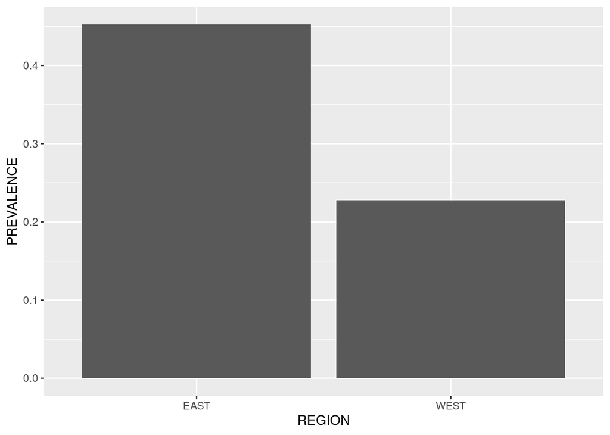

```r
ggplot(data = dr.prevalence.region,
       aes(x = REGION, y = PREVALENCE))+
  geom_bar(stat="identity",position="dodge")
```

Where is prevalence higher, east or west?

## 3.1 Calculate confidence intervals

Let’s first calculate the confidence interval for the country as a whole:

```r
PREVALENCE = sum(dr.data.filtered$ALT_ALLELE,na.rm = T)/(sum(dr.data.filtered$ALT_ALLELE,na.rm = T)+sum(dr.data.filtered$REF_ALLELE,na.rm = T))
N = sum(dr.data.filtered$ALT_ALLELE,na.rm = T) + sum(dr.data.filtered$REF_ALLELE,na.rm = T)
CI.LOWER = PREVALENCE - 1.96 * sqrt(PREVALENCE * (1 - PREVALENCE)/N)
CI.UPPER = PREVALENCE + 1.96 * sqrt(PREVALENCE * (1 - PREVALENCE)/N)
c(PREVALENCE,CI.LOWER,CI.UPPER)
```

```
## [1] 0.3557692 0.3146202 0.3969182
```

Does your response to the question “What codon has a higher prevalence?” change now that you have seen confident intervals? We will talk about uncertainty next!

Now let’s calculate the confidence intervals for the prevalence in each region, which will be easier with tidyverse tools:

```r
dr.prevalence.region <- dr.data.filtered %>%
  group_by(REGION) %>%
  summarise(PREVALENCE = sum(REF_WSAF<1,na.rm=T)/(sum(REF_WSAF<1,na.rm=T) + sum(REF_WSAF>0,na.rm=T)),
            N = sum(REF_WSAF<1,na.rm=T) + sum(REF_WSAF>0,na.rm=T)) %>%
  mutate(ci.lower = PREVALENCE - 1.96 * sqrt(PREVALENCE * (1 - PREVALENCE)/N),
         ci.upper = PREVALENCE + 1.96 * sqrt(PREVALENCE * (1 - PREVALENCE)/N))
dr.prevalence.region
```

```
## # A tibble: 2 × 5
##   REGION PREVALENCE     N ci.lower ci.upper
##   <chr>       <dbl> <int>    <dbl>    <dbl>
## 1 EAST        0.453   296    0.396    0.509
## 2 WEST        0.228   224    0.173    0.283
```

Does your response to the question “In which region is there higher prevalence?” change? What about the other codons in your group?

Now let’s add that new information to our visualization:

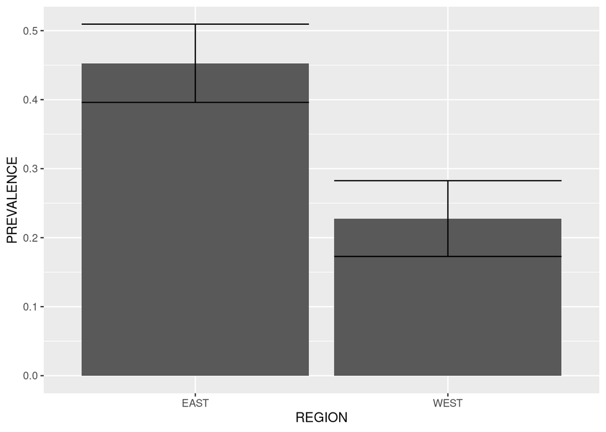

```r
ggplot(data = dr.prevalence.region,
       aes(x = REGION, y = PREVALENCE,ymin=ci.lower,ymax=ci.upper))+
  geom_bar(stat="identity",position="dodge")+
  geom_errorbar()
```

## 3.2 Integrating data from multiple codons

Now that each of you has worked on a codon independently, it’s time to put all of them together in one figure:

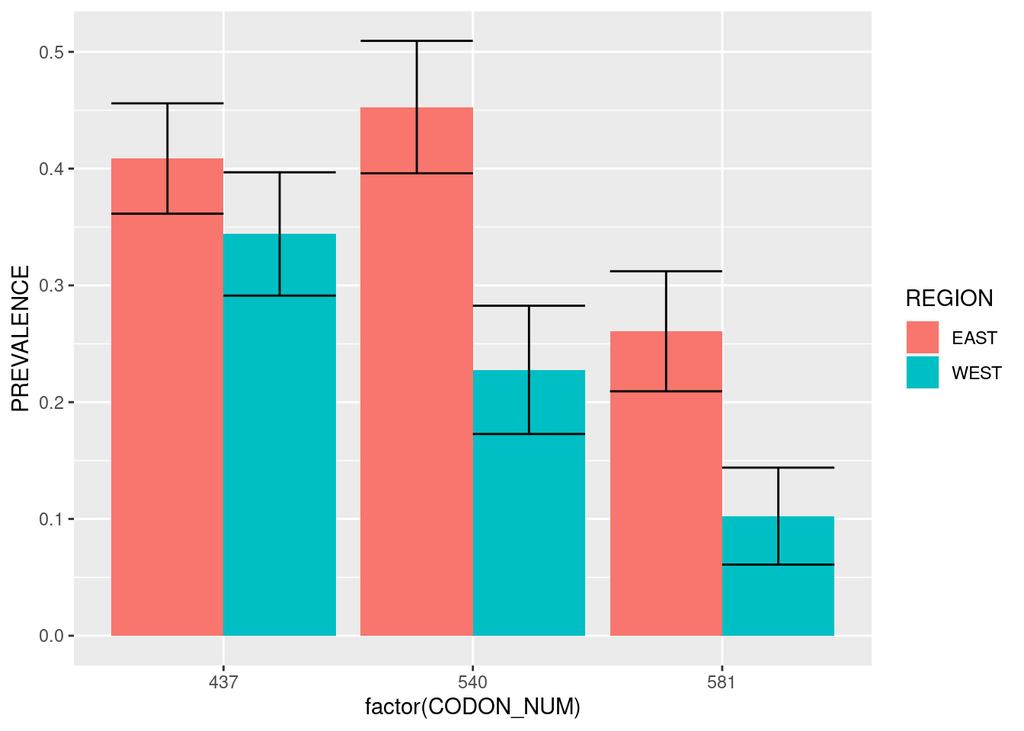

```r
dr.data.grouped.wald <- dr.data %>%
  group_by(CODON_NUM,REGION) %>%
  summarise(PREVALENCE = sum(REF_WSAF<1,na.rm=T)/(sum(REF_WSAF<1,na.rm=T) + sum(REF_WSAF>0,na.rm=T)),
            N = (sum(REF_WSAF<1,na.rm=T) + sum(REF_WSAF>0,na.rm=T))) %>%
  mutate(ci.lower = PREVALENCE - 1.96 * sqrt(PREVALENCE * (1 - PREVALENCE)/N),
         ci.upper = PREVALENCE + 1.96 * sqrt(PREVALENCE * (1 - PREVALENCE)/N))

ggplot(data = dr.data.grouped.wald,
       aes (fill = REGION,
            y = PREVALENCE,
            x = factor(CODON_NUM),
            ymin = ci.lower,
            ymax = ci.upper))+
  geom_bar(stat="identity",position="dodge")+
  geom_errorbar(position="dodge")
```

# 4 Visualizing haplotypes

Documentation on the package can be found here: https://cran.r-project.org/web/packages/UpSetR/UpSetR.pdf

Polyclonal data presents a challenge for haplotypes: if a sample contains 2 alleles for 2 loci, which allele goes with which in each of the parasites in that infection? To simplify our data set, we will remove samples with NAs and consider only the most abundant allele in each sample

```r
dr.data.NA = dr.data %>%
  group_by(SAMPLE_ID) %>%
  summarise(na = !any(is.na(REF_WSAF)))

dr.data.simplified <- dr.data %>%
  mutate(REF_WSAF_ROUND = round(REF_WSAF)) %>%
  filter(SAMPLE_ID %in% (dr.data.NA %>% filter(na))$SAMPLE_ID)
```

```r
dr.data.simplified %>%
  select(SAMPLE_ID,CODON_NUM,REF_WSAF_ROUND) %>%
  pivot_wider(names_from = CODON_NUM , values_from = REF_WSAF_ROUND) %>%
  mutate(haplotype = paste(`437`,`540`,`581`)) %>%
  group_by(haplotype) %>%
  summarize( n = n())
```

```
## # A tibble: 6 × 2
##   haplotype     n
##   <chr>     <int>
## 1 0 0 0         1
## 2 0 0 1         1
## 3 0 1 1       126
## 4 1 0 0        44
## 5 1 0 1        76
## 6 1 1 1       162
```

Advanced (long exercise) # Estimate CI using epitools’ binom.exact()

```r
dr.data.grouped.binom.exact <- dr.data %>%
  group_by(CODON_NUM,REGION) %>%
  summarise(X = sum(REF_WSAF<1,na.rm=T),
            N = (sum(REF_WSAF<1,na.rm=T) + sum(REF_WSAF>0,na.rm=T))) %>%
  mutate(ci = binom.exact(X,N,conf.level = 0.95))
```

Advanced: calculate how many samples have more than 1 allele